# HW3

Emanuele Iaccarino

2025-02-16

```r
load("hw_data.RData")
# Question: In bachelor degree we used to import dataset from environment section, the Import Dataset is easy to use but in this case it bugs, like among all the encoder no one works and it shows only messy simbols and characters, I was curious about why this method works and the other doesn't
speed_cols <- paste0("sp.", 1:60)
altitude_cols <- paste0("al.", 1:60)
```

```r
library(moments)  # For skewness and kurtosis
#install.packages("TTR")
library(TTR)
#install.packages("zoo")
library(zoo) # For mooving avg
#install.packages("signal")
library(signal)  # For FFT
df_features <- data.frame(matrix(nrow = nrow(hw), ncol = 0)) # initialization to match hw

# Workflow: In our group we have all done a few exams of economis/econometric so we have experience into working with time series: Choosing the right variables is 90% of the problem almost so we putted a lot of effort on this part
# I used to work with Gretl(econometric software) so I used all the trick implemented there to get more info as possible from time series data, maximizing the information we have and reducing the diemesion of the dataset

# --- Speed Features ---
# mean speed
df_features$Mean_Speed <- rowMeans(hw[, speed_cols], na.rm = TRUE)
# sd speed
df_features$SD_Speed <- apply(hw[, speed_cols], 1, function(x) ifelse(all(is.na(x)), NA, sd(x, na.rm = TRUE)))
# max speed
df_features$Max_Speed <- apply(hw[, speed_cols], 1, function(x) ifelse(all(is.na(x)), NA, max(x, na.rm = TRUE)))
# min speed
df_features$Min_Speed <- apply(hw[, speed_cols], 1, function(x) ifelse(all(is.na(x)), NA, min(x, na.rm = TRUE)))
# range speed
df_features$Range_Speed <- df_features$Max_Speed - df_features$Min_Speed
# median speed
df_features$Median_Speed <- apply(hw[, speed_cols], 1, function(x) ifelse(all(is.na(x)), NA, median(x, na.rm = TRUE)))
# skewness of the speeed
df_features$Skew_Speed <- apply(hw[, speed_cols], 1, function(x) ifelse(all(is.na(x)), NA, skewness(x, na.rm = TRUE)))
# kurtosis of the speed
df_features$Kurt_Speed <- apply(hw[, speed_cols], 1, function(x) ifelse(all(is.na(x)), NA, kurtosis(x, na.rm = TRUE)))

# --- Speed Features advanced feature extraction ---

# Slope change (It should represent an accelleration)
df_features$FDV_Speed <- apply(hw[, speed_cols], 1, function(x) ifelse(all(is.na(x)), NA, sd(diff(x, na.rm = TRUE))))

# --- Smooth Trend Features to take into consideration a bigger windows of data, using the neighbourhood observation to extend instant data acquisition to a certain time interval
# Moving Average and Moving Median
df_features$MovAvg_Speed <- apply(hw[, speed_cols], 1, function(x) ifelse(all(is.na(x)), NA, mean(rollmean(x, k = 5, fill = NA, align = "right"), na.rm = TRUE)))
# Moving Median
df_features$MovMed_Speed <- apply(hw[, speed_cols], 1, function(x) ifelse(all(is.na(x)), NA, median(rollmedian(x, k = 5, fill = NA, align = "right"), na.rm = TRUE)))

# Entropy of frequency components
# https://www.mathworks.com/help/signal/ref/spectralentropy.html
# converts  time-series signal from the time domain to the frequency domain. Instead of looking at how speed changes over time, we analyze which frequencies dominate the signal
# Low entropy: Fewer frequency components contribute to speed variation.
# High entropy: A more complex and unpredictable pattern of speed changes.

df_features$FFT_Entropy_Speed <- apply(hw[, speed_cols], 1, function(x) {
  x[is.na(x)] <- 0
  fft_vals <- abs(fft(x))
  fft_probs <- fft_vals / sum(fft_vals)
  return(-sum(fft_probs * log(fft_probs + 1e-10)))
})

# Absolute Speed
df_features$RMS_Speed <- apply(hw[, speed_cols], 1, function(x) {
  sqrt(mean(x^2, na.rm = TRUE))
})

# --- Altitude Features ---
# mean altitude
df_features$Mean_Altitude <- rowMeans(hw[, altitude_cols], na.rm = TRUE)
# sd altitude
df_features$SD_Altitude <- apply(hw[, altitude_cols], 1, function(x) ifelse(all(is.na(x)), NA, sd(x, na.rm = TRUE)))
# max altitude
df_features$Max_Altitude <- apply(hw[, altitude_cols], 1, function(x) ifelse(all(is.na(x)), NA, max(x, na.rm = TRUE)))
# min altitude
df_features$Min_Altitude <- apply(hw[, altitude_cols], 1, function(x) ifelse(all(is.na(x)), NA, min(x, na.rm = TRUE)))
# range altitude
df_features$Range_Altitude <- df_features$Max_Altitude - df_features$Min_Altitude
# median altitude
df_features$Median_Altitude <- apply(hw[, altitude_cols], 1, function(x) ifelse(all(is.na(x)), NA, median(x, na.rm = TRUE)))
# Skweness of the altitude
df_features$Skew_Altitude <- apply(hw[, altitude_cols], 1, function(x) ifelse(all(is.na(x)), NA, skewness(x, na.rm = TRUE)))
# Kurtosis of the altitude
df_features$Kurt_Altitude <- apply(hw[, altitude_cols], 1, function(x) ifelse(all(is.na(x)), NA, kurtosis(x, na.rm = TRUE)))

# --- Altitude Features advanced feature extraction ---

# Slope Changes (We can interpretate it as elevation difference)
df_features$FDV_Altitude <- apply(hw[, altitude_cols], 1, function(x) ifelse(all(is.na(x)), NA, sd(diff(x, na.rm = TRUE))))

# Moving Average
df_features$MovAvg_Altitude <- apply(hw[, altitude_cols], 1, function(x) ifelse(all(is.na(x)), NA, mean(rollmean(x, k = 5, fill = NA, align = "right"), na.rm = TRUE)))
# Moving Median
df_features$MovMed_Altitude <- apply(hw[, altitude_cols], 1, function(x) ifelse(all(is.na(x)), NA, median(rollmedian(x, k = 5, fill = NA, align = "right"), na.rm = TRUE)))
# Entropy of frequency components
df_features$FFT_Entropy_Altitude <- apply(hw[, altitude_cols], 1, function(x) {
  x[is.na(x)] <- 0
  fft_vals <- abs(fft(x))
  fft_probs <- fft_vals / sum(fft_vals)
  return(-sum(fft_probs * log(fft_probs + 1e-10)))
})
# Here the results are slightly different from the speed
# If altitude fluctuates significantly (Not flat), FFT entropy may help detect patterns.
# If altitude is mostly flat (track running), then FFT entropy might not be useful.

# Absolute Altitude (Root Mean Square of Altitude)
df_features$RMS_Altitude <- apply(hw[, altitude_cols], 1, function(x) {
  sqrt(mean(x^2, na.rm = TRUE))
})

df_features$HR_Zone <- hw$y
head(df_features)
```

```
##   Mean_Speed   SD_Speed Max_Speed Min_Speed Range_Speed Median_Speed
## 1   2.830883 0.09334955     2.996     2.654       0.342       2.8430
## 2   3.516350 0.22509138     3.797     2.385       1.412       3.5415
## 3   2.936483 0.85378216     4.733     1.484       3.249       2.8710
## 4   3.490450 0.15362373     3.902     3.251       0.651       3.4740
## 5   3.681683 0.08351464     3.845     3.499       0.346       3.7020
## 6   2.497667 0.20585503     2.855     2.139       0.716       2.4795
##    Skew_Speed Kurt_Speed  FDV_Speed MovAvg_Speed MovMed_Speed FFT_Entropy_Speed
## 1 -0.15264229   1.796742 0.02896743     2.836961       2.8605         0.7479129
## 2 -2.73902814  12.901860 0.08941445     3.539546       3.5355         1.7046429
## 3  0.46993934   2.760842 0.30430148     2.958129       2.8600         2.5330640
## 4  0.84841311   3.511816 0.05170232     3.502868       3.4810         0.9126984
## 5 -0.64059107   2.909989 0.02703349     3.685446       3.7020         0.5795897
## 6  0.08923606   1.948597 0.05946971     2.499950       2.4825         1.2044793
##   RMS_Speed Mean_Altitude SD_Altitude Max_Altitude Min_Altitude Range_Altitude
```

[output cut: 20 more lines]

```r
#summary(df_features)
```

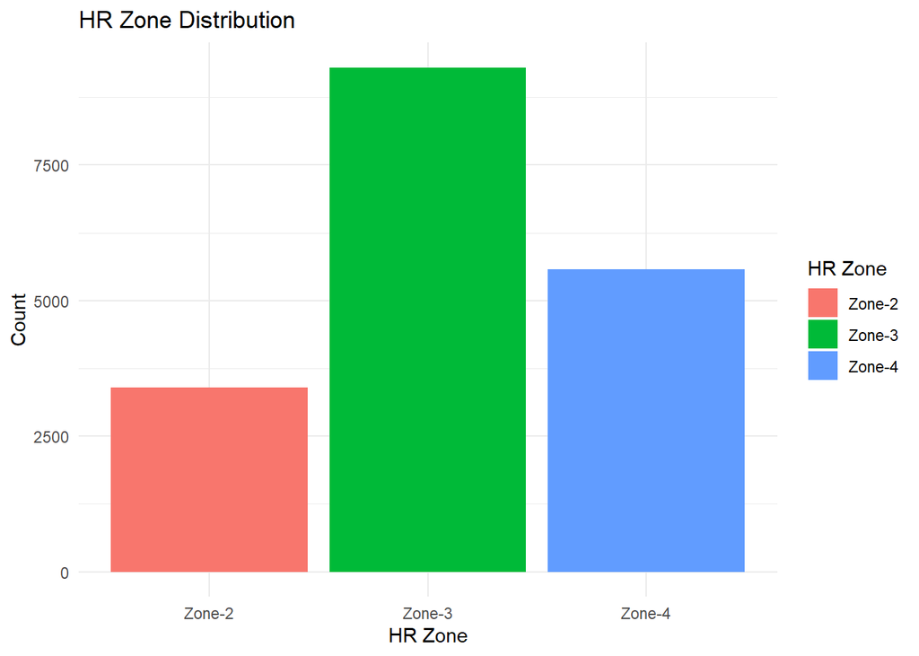

```r
library(ggplot2)
ggplot(df_features, aes(x = as.factor(HR_Zone), fill = as.factor(HR_Zone))) +
  geom_bar() +
  labs(title = "HR Zone Distribution",
       x = "HR Zone",
       y = "Count",
       fill = "HR Zone") +
  theme_minimal()
```

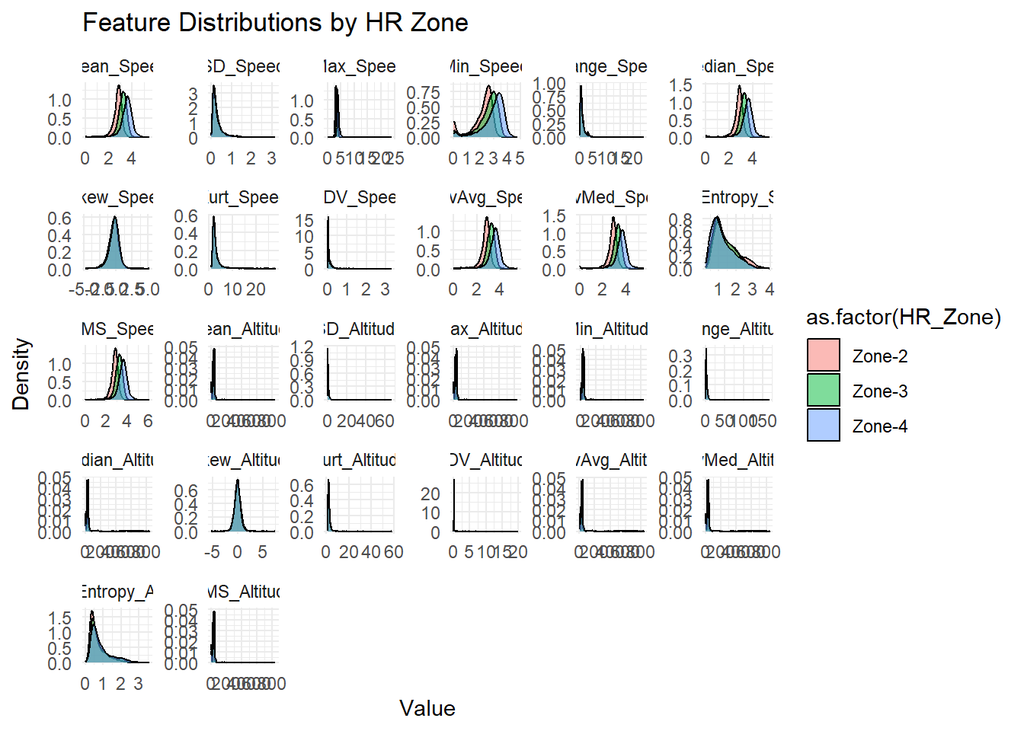

```r
library(reshape2)

df_melted <- melt(df_features, id.vars = "HR_Zone")

ggplot(df_melted, aes(x = value, fill = as.factor(HR_Zone))) +
  geom_density(alpha = 0.5) +
  facet_wrap(~variable, scales = "free") +
  labs(title = "Feature Distributions by HR Zone",
       x = "Value",
       y = "Density") +
  theme_minimal()
```

We can see how just a few of the features we created are able to clearly separated the different zones, some of them can be also removed to make our model more simple but we’ll deal with that later

ALso we learned that the Zones are in order, speed variables are the one who will weight more in the model, while “ad occhio, sorry for italian” the only altitude variable that seams to matter a little is entropy

```r
# Count total missing values in the dataset
sum(is.na(df_features))
```

```
## [1] 17
```

```r
# Count missing values per feature
colSums(is.na(df_features))
```

```
##           Mean_Speed             SD_Speed            Max_Speed
##                    0                    0                    0
##            Min_Speed          Range_Speed         Median_Speed
##                    0                    0                    0
##           Skew_Speed           Kurt_Speed            FDV_Speed
##                    3                    3                    1
##         MovAvg_Speed         MovMed_Speed    FFT_Entropy_Speed
##                    0                    0                    3
##            RMS_Speed        Mean_Altitude          SD_Altitude
##                    0                    0                    0
##         Max_Altitude         Min_Altitude       Range_Altitude
##                    0                    0                    0
##      Median_Altitude        Skew_Altitude        Kurt_Altitude
##                    0                    3                    3
##         FDV_Altitude      MovAvg_Altitude      MovMed_Altitude
##                    1                    0                    0
## FFT_Entropy_Altitude         RMS_Altitude              HR_Zone
##                    0                    0                    0
```

WHY? Well Skewness/Kurtosis/FFT fail when all values are the same so variance is 0

```r
threshold <- 0.05 * nrow(df_features)
df_features <- df_features[, colSums(is.na(df_features)) < threshold]
sum(is.na(df_features))
```

```
## [1] 17
```

Never luck :( We impute with median to deal with outliers, it’s the easier and less expensive computationally speaking way to deal with this problem

```r
for (col in colnames(df_features)) {
  if (sum(is.na(df_features[[col]])) > 0) {  # If column has NAs
    df_features[[col]][is.na(df_features[[col]])] <- median(df_features[[col]], na.rm = TRUE)
  }
}
sum(is.na(df_features))
```

```
## [1] 0
```

This is my favourite classification trick, learned by nerding on Kaggle Playground competition a few years ago. PCA shows intuitively how easily the dataset is separable, we can more or less guess how much accuracy we can expect from our model

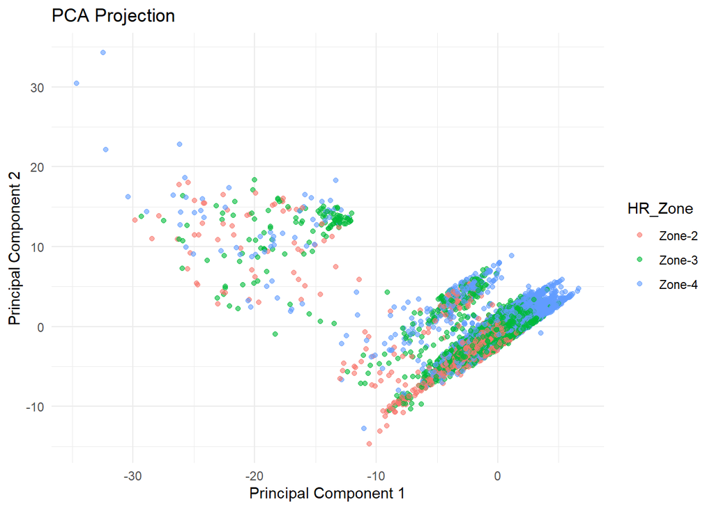

```r
pca_data <- df_features[, !names(df_features) %in% "HR_Zone"]
pca_result <- prcomp(pca_data, scale. = TRUE) # FactorMineR was giving me problem
pca_df <- data.frame(pca_result$x[, 1:2], HR_Zone = df_features$HR_Zone)

ggplot(pca_df, aes(x = PC1, y = PC2, color = HR_Zone)) +
  geom_point(alpha = 0.6) +
  labs(title = "PCA Projection", x = "Principal Component 1", y = "Principal Component 2") +
  theme_minimal()
```

I hoped in better results, anyway let’s get more info:

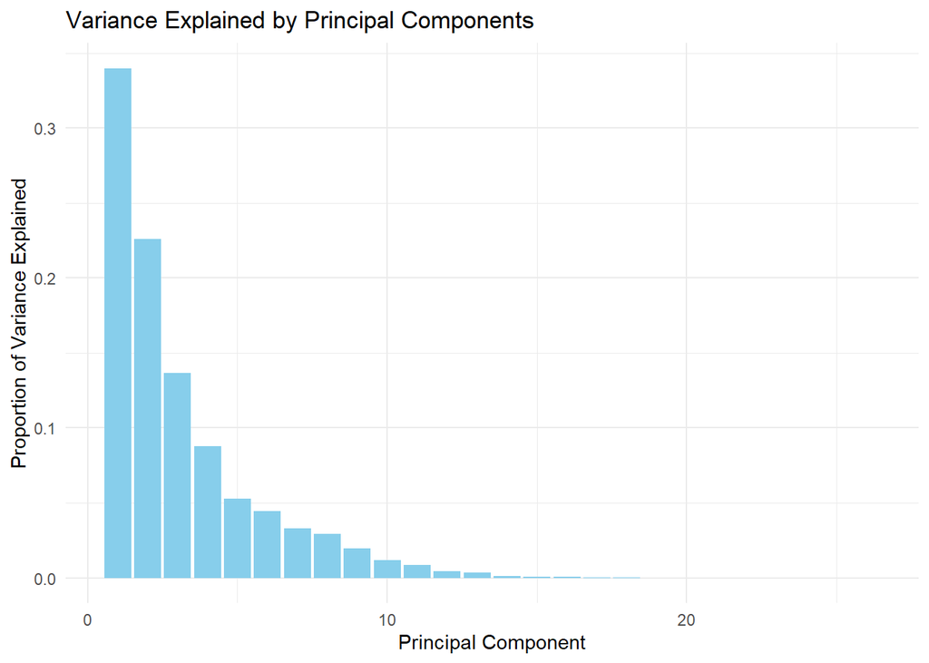

```r
library(ggplot2)

explained_variance <- (pca_result$sdev^2) / sum(pca_result$sdev^2)
cumulative_variance <- cumsum(explained_variance)

var_df <- data.frame(
  PC = 1:length(explained_variance),
  Variance_Explained = explained_variance, # variance explained by each PC
  Cumulative_Variance = cumulative_variance # how many PCs retain most of the info
)

# Plots
ggplot(var_df, aes(x = PC, y = Variance_Explained)) +
  geom_col(fill = "skyblue") +
  labs(title = "Variance Explained by Principal Components",
       x = "Principal Component",
       y = "Proportion of Variance Explained") +
  theme_minimal()
```

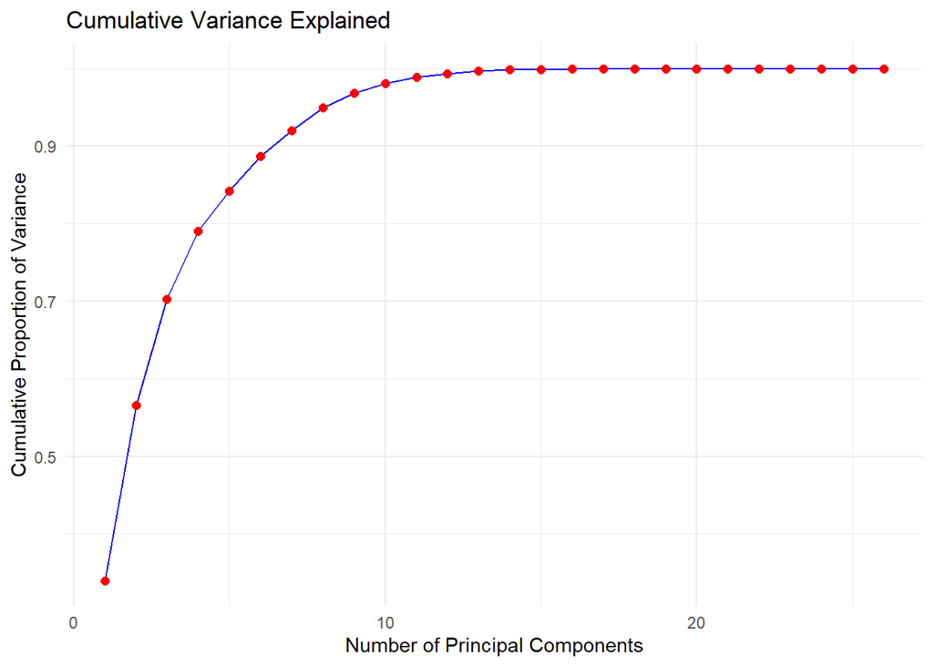

```r
ggplot(var_df, aes(x = PC, y = Cumulative_Variance)) +
  geom_line(color = "blue") + geom_point(size = 2, color = "red") +
  labs(title = "Cumulative Variance Explained",
       x = "Number of Principal Components",
       y = "Cumulative Proportion of Variance") +
  theme_minimal()
```

Initially we went straight to modeling and find out there is high correlation between the features we created (it’s quite normal), so let’s get deeper information and deal with it

```r
# Convert HR_Zone to numeric values
df_features$HR_Zone <- ifelse(df_features$HR_Zone == "Zone-2", 0,
                       ifelse(df_features$HR_Zone == "Zone-3", 1, 2))

df_features_clean <- df_features[, !colnames(df_features) %in% "HR_Zone"] # remove target
```

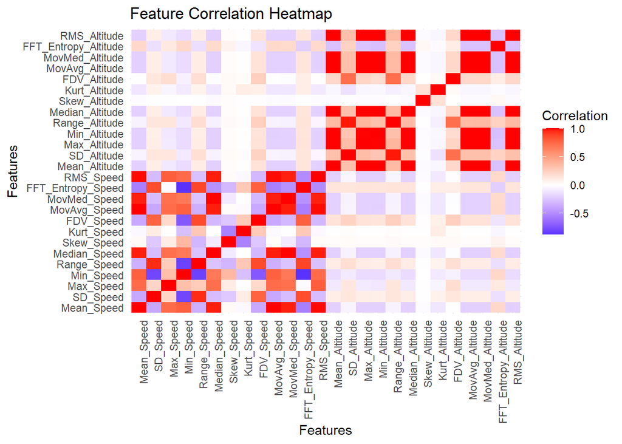

```r
library(ggplot2)
library(reshape2)
library(corrplot)
cor_matrix <- cor(df_features_clean, use = "pairwise.complete.obs")
cor_data <- melt(cor_matrix)

ggplot(cor_data, aes(x=Var1, y=Var2, fill=value)) +
  geom_tile() +
  scale_fill_gradient2(low = "blue", mid = "white", high = "red", midpoint = 0) +
  labs(title = "Feature Correlation Heatmap", x = "Features", y = "Features", fill = "Correlation") +
  theme_minimal() +
  theme(axis.text.x = element_text(angle = 90, hjust = 1))
```

```r
library(caret)
high_corr_features <- findCorrelation(cor_matrix, cutoff = 0.9, verbose = TRUE)
```

```
## Compare row 1  and column  10 with corr  0.999
##   Means:  0.36 vs 0.271 so flagging column 1
## Compare row 16  and column  24 with corr  1
##   Means:  0.366 vs 0.263 so flagging column 16
## Compare row 10  and column  13 with corr  0.992
##   Means:  0.337 vs 0.255 so flagging column 10
## Compare row 24  and column  19 with corr  1
##   Means:  0.343 vs 0.247 so flagging column 24
## Compare row 19  and column  26 with corr  1
##   Means:  0.312 vs 0.239 so flagging column 19
## Compare row 26  and column  23 with corr  1
##   Means:  0.277 vs 0.233 so flagging column 26
## Compare row 23  and column  14 with corr  1
##   Means:  0.239 vs 0.23 so flagging column 23
## Compare row 14  and column  17 with corr  1
##   Means:  0.196 vs 0.232 so flagging column 17
## Compare row 13  and column  6 with corr  0.97
##   Means:  0.322 vs 0.229 so flagging column 13
## Compare row 6  and column  11 with corr  0.998
##   Means:  0.278 vs 0.22 so flagging column 6
## Compare row 5  and column  2 with corr  0.948
##   Means:  0.363 vs 0.209 so flagging column 5
## Compare row 18  and column  15 with corr  0.981
##   Means:  0.23 vs 0.193 so flagging column 18
## All correlations <= 0.9
```

```r
high_corr_features
```

```
##  [1]  1 16 10 24 19 26 23 17 13  6  5 18
```

```r
cor_with_target <- cor(df_features_clean, df_features$HR_Zone, use = "pairwise.complete.obs") # corr with target

cor_with_target_abs <- abs(cor_with_target) # to deal equally with - and + corr
cor_with_target_sorted <- sort(cor_with_target_abs, decreasing = TRUE)
selected_features <- colnames(df_features_clean)

for (i in high_corr_features) {
  feature_1 <- colnames(df_features_clean)[i]
    correlated_pairs <- which(abs(cor_matrix[, i]) > 0.9)
    if (length(correlated_pairs) > 1) {
    best_feature <- names(which.max(cor_with_target_abs[correlated_pairs]))
    selected_features <- selected_features[!selected_features %in% feature_1]
  }
}

# Keep only the selected features
df_selected <- df_features_clean[, selected_features]

head(df_selected)
```

```
##     SD_Speed Max_Speed Min_Speed  Skew_Speed Kurt_Speed  FDV_Speed MovMed_Speed
## 1 0.09334955     2.996     2.654 -0.15264229   1.796742 0.02896743       2.8605
## 2 0.22509138     3.797     2.385 -2.73902814  12.901860 0.08941445       3.5355
## 3 0.85378216     4.733     1.484  0.46993934   2.760842 0.30430148       2.8600
## 4 0.15362373     3.902     3.251  0.84841311   3.511816 0.05170232       3.4810
## 5 0.08351464     3.845     3.499 -0.64059107   2.909989 0.02703349       3.7020
## 6 0.20585503     2.855     2.139  0.08923606   1.948597 0.05946971       2.4825
##   FFT_Entropy_Speed Mean_Altitude SD_Altitude Skew_Altitude Kurt_Altitude
## 1         0.7479129      23.90333   0.4737040   0.009905776      1.617172
## 2         1.7046429      33.47000   0.4965303  -0.345603049      2.012677
## 3         2.5330640      31.78667   1.3904598   0.008665452      1.611080
## 4         0.9126984      22.95667   0.2993590  -0.787329066      2.512855
## 5         0.5795897      16.05333   0.5714883   0.941736494      2.901141
## 6         1.2044793      43.77333   1.1860584  -0.862472933      2.379040
##   FDV_Altitude FFT_Entropy_Altitude
## 1    0.1270075            0.5036543
## 2    0.1140099            0.3334350
## 3    0.3256069            0.7131969
## 4    0.1166451            0.4307289
## 5    0.2161239            0.8377464
## 6    0.1586766            0.7263730
```

```r
print(selected_features) # feature removed
```

```
##  [1] "SD_Speed"             "Max_Speed"            "Min_Speed"
##  [4] "Skew_Speed"           "Kurt_Speed"           "FDV_Speed"
##  [7] "MovMed_Speed"         "FFT_Entropy_Speed"    "Mean_Altitude"
## [10] "SD_Altitude"          "Skew_Altitude"        "Kurt_Altitude"
## [13] "FDV_Altitude"         "FFT_Entropy_Altitude"
```

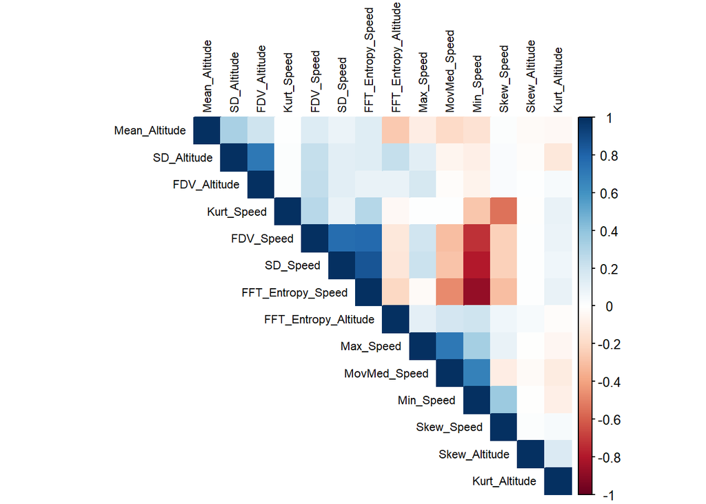

```r
cor_matrix_filtered <- cor(df_selected, use = "pairwise.complete.obs")
corrplot(cor_matrix_filtered, method = "color", type = "upper", tl.cex = 0.7, tl.col = "black", order = "hclust")
```

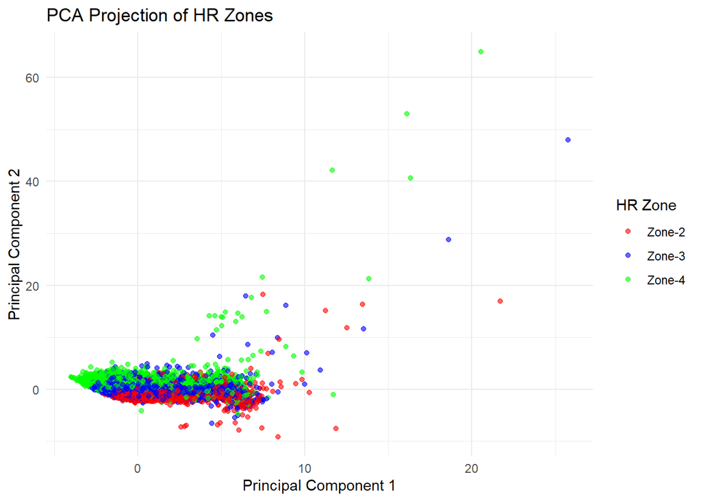

```r
pca_data <- df_selected[, !names(df_selected) %in% "HR_Zone"]
pca_result <- prcomp(pca_data, scale. = TRUE)
pca_df <- data.frame(pca_result$x[, 1:2], HR_Zone = df_features$HR_Zone)

pca_df$HR_Zone <- factor(pca_df$HR_Zone, levels = c(0, 1, 2),
                          labels = c("Zone-2", "Zone-3", "Zone-4"))
hr_zone_colors <- c("Zone-2" = "red", "Zone-3" = "blue", "Zone-4" = "green")

ggplot(pca_df, aes(x = PC1, y = PC2, color = HR_Zone)) +
  geom_point(alpha = 0.6) +
  scale_color_manual(values = hr_zone_colors) +
  labs(title = "PCA Projection of HR Zones",
       x = "Principal Component 1",
       y = "Principal Component 2",
       color = "HR Zone") +
  theme_minimal()
```

Slightly better to be honest, we can see that each zone density is more or less compact

We will perform the test for Zone-2 vs Zone-3 first.

```r
# Filter
df_subset <- df_selected[df_features$HR_Zone %in% c(0, 1), ]

# Add HR_Zone column explicitly from df_selected
df_subset$HR_Zone <- df_features$HR_Zone[df_features$HR_Zone %in% c(0, 1)]

# Convert HR_Zone into a factor with meaningful labels
df_subset$HR_Zone <- factor(df_subset$HR_Zone, levels = c(0, 1), labels = c("Zone-2", "Zone-3"))

# Check if HR_Zone is correctly included
table(df_subset$HR_Zone)
```

```
##
## Zone-2 Zone-3
##   3399   9299
```

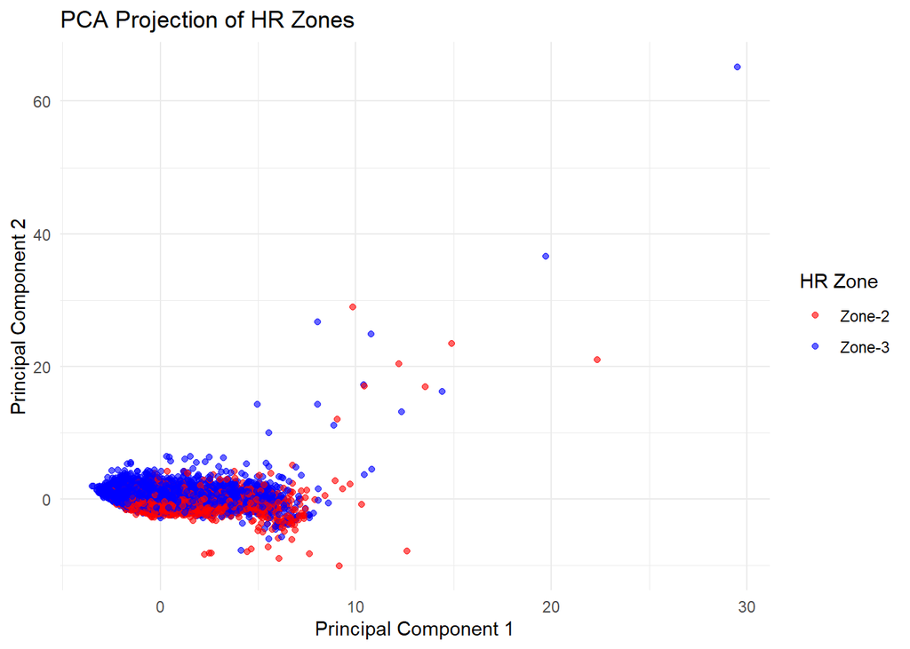

```r
pca_data <- df_subset[, !names(df_subset) %in% "HR_Zone"]
pca_result <- prcomp(pca_data, scale. = TRUE)
pca_df <- data.frame(pca_result$x[, 1:2], HR_Zone = df_features$HR_Zone[df_features$HR_Zone %in% c(0, 1)])

pca_df$HR_Zone <- factor(pca_df$HR_Zone, levels = c(0, 1),
                          labels = c("Zone-2", "Zone-3"))
hr_zone_colors <- c("Zone-2" = "red", "Zone-3" = "blue")

ggplot(pca_df, aes(x = PC1, y = PC2, color = HR_Zone)) +
  geom_point(alpha = 0.6) +
  scale_color_manual(values = hr_zone_colors) +
  labs(title = "PCA Projection of HR Zones",
       x = "Principal Component 1",
       y = "Principal Component 2",
       color = "HR Zone") +
  theme_minimal()
```

```r
set.seed(42)  # For reproducibility
df_subset$HR_Zone <- ifelse(df_subset$HR_Zone == "Zone-2", 0, 1)
# Split data into 80% training and 20% testing
train_index <- createDataPartition(df_subset$HR_Zone, p = 0.8, list = FALSE)
train_data <- df_subset[train_index, ]
test_data <- df_subset[-train_index, ]
#sum(is.na(train_data))
#sum(is.na(test_data))

class_counts <- table(train_data$HR_Zone)
class_weights <- 1 / class_counts
weights_vector <- ifelse(train_data$HR_Zone == 0, class_weights[1], class_weights[2])

# Train Logistic Regression Model
model <- glm(HR_Zone ~ ., data = train_data, family = binomial(), weights = weights_vector)
# Predict on Test Set
pred_probs <- predict(model, test_data, type = "response")  # Store `pred_probs`
pred_labels <- ifelse(pred_probs > 0.5, 1, 0)

# Compute Confusion Matrix
library(caret)
conf_matrix <- confusionMatrix(as.factor(pred_labels), as.factor(test_data$HR_Zone))
print(conf_matrix)
```

```
## Confusion Matrix and Statistics
##
##           Reference
## Prediction    0    1
##          0  503  452
##          1  156 1428
##
##                Accuracy : 0.7605
##                  95% CI : (0.7434, 0.777)
##     No Information Rate : 0.7404
##     P-Value [Acc > NIR] : 0.01066
##
##                   Kappa : 0.4563
##
##  Mcnemar's Test P-Value : < 2e-16
##
##             Sensitivity : 0.7633
##             Specificity : 0.7596
##          Pos Pred Value : 0.5267
##          Neg Pred Value : 0.9015
##              Prevalence : 0.2596
##          Detection Rate : 0.1981
##    Detection Prevalence : 0.3761
##       Balanced Accuracy : 0.7614
##
##        'Positive' Class : 0
##
```

```r
# Lower decision threshold to improve sensitivity
pred_labels_adj <- ifelse(pred_probs > 0.4, 1, 0)

conf_matrix_adj <- confusionMatrix(as.factor(pred_labels_adj), as.factor(test_data$HR_Zone))
print(conf_matrix_adj)
```

```
## Confusion Matrix and Statistics
##
##           Reference
## Prediction    0    1
##          0  427  293
##          1  232 1587
##
##                Accuracy : 0.7932
##                  95% CI : (0.7769, 0.8088)
##     No Information Rate : 0.7404
##     P-Value [Acc > NIR] : 3.039e-10
##
##                   Kappa : 0.4777
##
##  Mcnemar's Test P-Value : 0.008829
##
##             Sensitivity : 0.6480
##             Specificity : 0.8441
##          Pos Pred Value : 0.5931
##          Neg Pred Value : 0.8725
##              Prevalence : 0.2596
##          Detection Rate : 0.1682
##    Detection Prevalence : 0.2836
##       Balanced Accuracy : 0.7461
##
##        'Positive' Class : 0
##
```

We get slighly better results

```r
# Train Logistic Regression Model on Zone-2 vs Zone-3
model <- glm(HR_Zone ~ ., data = df_subset, family = binomial())
# Extract feature importance as absolute coefficients
feature_importance <- abs(coef(model)[-1])  # Remove intercept
importance_df <- data.frame(Feature = names(feature_importance), Importance = feature_importance)

# Sort features by importance
importance_df <- importance_df[order(-importance_df$Importance), ]

# Print top 10 most important features
print(head(importance_df, 10))
```

```
##                                   Feature Importance
## FDV_Speed                       FDV_Speed  2.5464521
## Max_Speed                       Max_Speed  2.5250831
## Min_Speed                       Min_Speed  1.1991743
## FFT_Entropy_Speed       FFT_Entropy_Speed  0.7388516
## FDV_Altitude                 FDV_Altitude  0.7046159
## FFT_Entropy_Altitude FFT_Entropy_Altitude  0.4637374
## MovMed_Speed                 MovMed_Speed  0.3705939
## SD_Speed                         SD_Speed  0.3192621
## Skew_Speed                     Skew_Speed  0.3086055
## SD_Altitude                   SD_Altitude  0.2041223
```

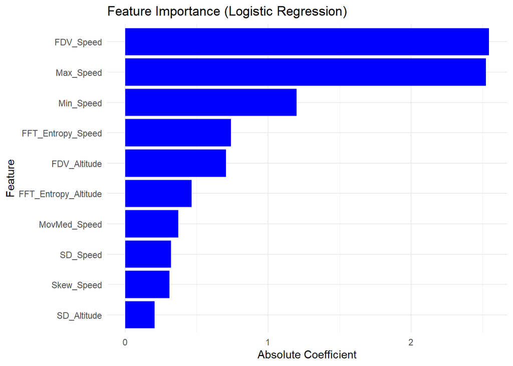

```r
# Plot feature importance
library(ggplot2)
ggplot(importance_df[1:10, ], aes(x = reorder(Feature, Importance), y = Importance)) +
  geom_bar(stat = "identity", fill = "blue") +
  coord_flip() +
  labs(title = "Feature Importance (Logistic Regression)", x = "Feature", y = "Absolute Coefficient") +
  theme_minimal()
```

Most important features, strange to see max and min cause they don’t hold a lot of information but probably the range of values is important to determine the zone

```r
ks_stat <- ks.test(pred_probs[which(test_data$HR_Zone == 0)],
                   pred_probs[which(test_data$HR_Zone == 1)])$statistic

P <- 100
perm_values <- numeric(P)

original_labels <- test_data$HR_Zone

for (p in 1:P) {
  permuted_data <- test_data
  permuted_data$HR_Zone <- sample(original_labels)  # Shuffle labels
  # Train model with error handling
  perm_model <- glm(HR_Zone ~ ., data = permuted_data, family = binomial())



  # Compute test statistic on permuted labels
  perm_preds <- predict(perm_model, type = "response")

  perm_values[p] <- ks.test(perm_preds[which(permuted_data$HR_Zone == 0)],
                            perm_preds[which(permuted_data$HR_Zone == 1)])$p.value
}

test_data$HR_Zone <- original_labels
alpha = 0.05
quantile_threshold <- quantile(perm_values, 1 - alpha)
power <- mean(ks_stat >= quantile_threshold)

cat("Observed KS Statistic:", ks_stat, "\n")
```

```
## Observed KS Statistic: 0.5299212
```

```r
cat("Mean KS Statistic from Permutation:", mean(perm_values), "\n")
```

```
## Mean KS Statistic from Permutation: 0.04388648
```

```r
cat("1 - Alpha Quantile (95% Permuted KS):", quantile_threshold, "\n")
```

```
## 1 - Alpha Quantile (95% Permuted KS): 0.1690416
```

```r
cat("Estimated Power:", power, "\n")
```

```
## Estimated Power: 1
```

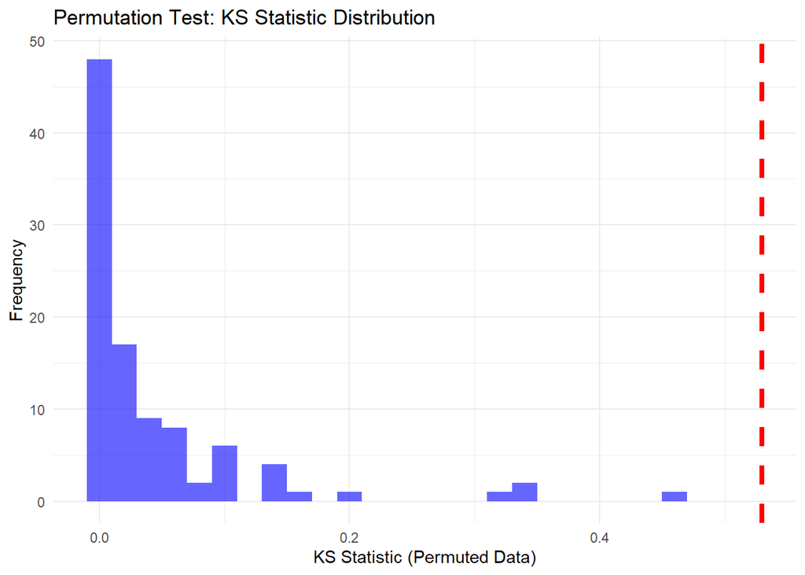

```r
library(ggplot2)

# Convert permutation results into a dataframe for visualization
perm_df <- data.frame(perm_values)

# Plot Histogram
ggplot(perm_df, aes(x = perm_values)) +
  geom_histogram(binwidth = 0.02, fill = "blue", alpha = 0.6) +
  geom_vline(xintercept = ks_stat, color = "red", linetype = "dashed", size = 1.5) +
  labs(title = "Permutation Test: KS Statistic Distribution",
       x = "KS Statistic (Permuted Data)",
       y = "Frequency") +
  theme_minimal()
```

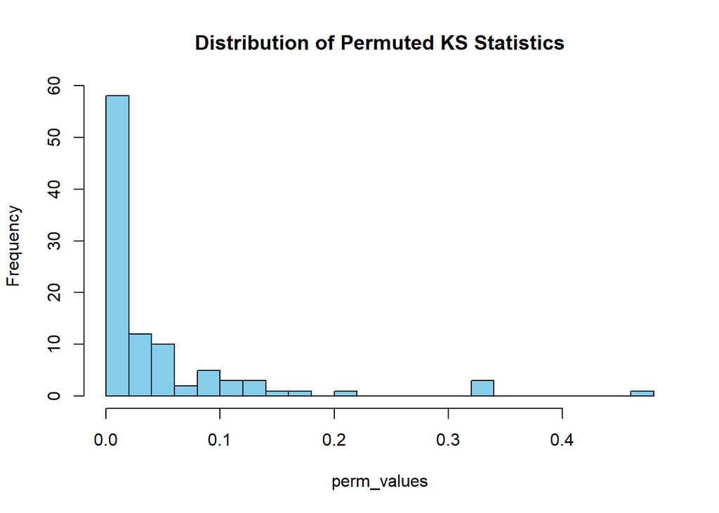

```r
hist(perm_values, breaks = 20, main = "Distribution of Permuted KS Statistics", col = "skyblue")
```

Honestly I’d have expected a lower value, power = 1 I think is wrong but I checked more than 10 times the implementation of Friedman’s paper and it seams correct :(

Anyway we give a try to the last part:

Since now we are dealing with 3 classes simoultaneously we use Multinomial Logistic Regression, that estimates probabilities for all classes. So now we have multiple logistic functions (one per class) and ofc ultiple decision boundaries (multi-class)

```r
library(nnet)

df_multiclass <- df_features[df_features$HR_Zone %in% c(0,1,2), ]
df_multiclass$HR_Zone <- factor(df_multiclass$HR_Zone, levels = c(0,1,2))

model_multi <- multinom(HR_Zone ~ ., data = df_multiclass)
pred_probs <- predict(model_multi, df_multiclass, type = "probs")

ks_23 <- ks.test(pred_probs[df_multiclass$HR_Zone == 0, 2],
                 pred_probs[df_multiclass$HR_Zone == 1, 2])$statistic
ks_34 <- ks.test(pred_probs[df_multiclass$HR_Zone == 1, 3],
                 pred_probs[df_multiclass$HR_Zone == 2, 3])$statistic
ks_24 <- ks.test(pred_probs[df_multiclass$HR_Zone == 0, 3],
                 pred_probs[df_multiclass$HR_Zone == 2, 3])$statistic

cat("KS Statistic Zone-2 vs Zone-3:", ks_23, "\n")
```

```
## KS Statistic Zone-2 vs Zone-3: 0.2734144
```

```r
cat("KS Statistic Zone-3 vs Zone-4:", ks_34, "\n")
```

```
## KS Statistic Zone-3 vs Zone-4: 0.4569934
```

```r
cat("KS Statistic Zone-2 vs Zone-4:", ks_24, "\n")
```

```
## KS Statistic Zone-2 vs Zone-4: 0.7911595
```

Well we have a weaker separation, a stronger separation and a very strong separation, this value makes totally sense seeing the distribution of our main variables. Those depends by how much the two distribution overlap and ofc Zone 2 and Zone 4 being more distanced have a larger value

We can now apply the Friedman’s test for the 3 case scenario as well

```r
set.seed(42)

P <- 100
perm_values_23 <- numeric(P)
perm_values_34 <- numeric(P)
perm_values_24 <- numeric(P)

original_labels <- df_multiclass$HR_Zone

for (p in 1:P) {
  permuted_data <- df_multiclass
  permuted_data$HR_Zone <- sample(original_labels)

  perm_model_multi <- tryCatch({
    multinom(HR_Zone ~ ., data = permuted_data)
  }, error = function(e) return(NULL))  # Handle errors

  if (is.null(perm_model_multi)) next # skip if fail

  perm_preds <- predict(perm_model_multi, permuted_data, type = "probs")

  perm_values_23[p] <- ks.test(perm_preds[permuted_data$HR_Zone == 0, 2],
                               perm_preds[permuted_data$HR_Zone == 1, 2])$statistic
  perm_values_34[p] <- ks.test(perm_preds[permuted_data$HR_Zone == 1, 3],
                               perm_preds[permuted_data$HR_Zone == 2, 3])$statistic
  perm_values_24[p] <- ks.test(perm_preds[permuted_data$HR_Zone == 0, 3],
                               perm_preds[permuted_data$HR_Zone == 2, 3])$statistic
}
df_multiclass$HR_Zone <- original_labels
alpha = 0.05
quantile_threshold_23 <- quantile(perm_values_23, 1 - alpha)
quantile_threshold_34 <- quantile(perm_values_34, 1 - alpha)
quantile_threshold_24 <- quantile(perm_values_24, 1 - alpha)

power <- mean(ks_stat >= quantile_threshold)

power_23 <- mean(ks_23 >= quantile_threshold_23)
power_34 <- mean(ks_34 >= quantile_threshold_34)
power_24 <- mean(ks_24 >= quantile_threshold_24)

cat("Estimated Power Zone-2 vs Zone-3:", power_23, "\n")
```

```
## Estimated Power Zone-2 vs Zone-3: 1
```

```r
cat("Estimated Power Zone-3 vs Zone-4:", power_34, "\n")
```

```
## Estimated Power Zone-3 vs Zone-4: 1
```

```r
cat("Estimated Power Zone-2 vs Zone-4:", power_24, "\n")
```

```
## Estimated Power Zone-2 vs Zone-4: 1
```

Power all equal to 1 :( I would expected only Zone 2 vs Zone 3 to get closer to it, we can confirm something is wrong :(((

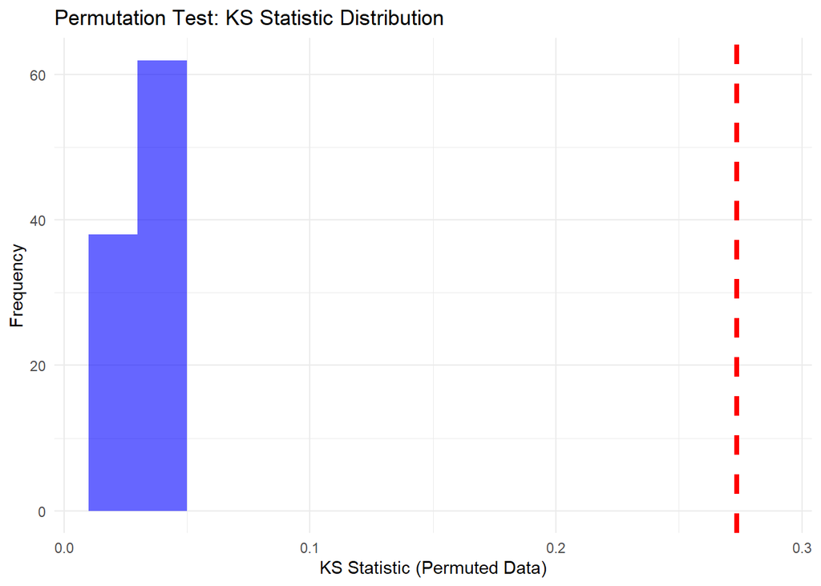

```r
perm_df_23 <- data.frame(perm_values_23)

ggplot(perm_df_23, aes(x = perm_values_23)) +
  geom_histogram(binwidth = 0.02, fill = "blue", alpha = 0.6) +
  geom_vline(xintercept = ks_23, color = "red", linetype = "dashed", size = 1.5) +
  labs(title = "Permutation Test: KS Statistic Distribution",
       x = "KS Statistic (Permuted Data)",
       y = "Frequency") +
  theme_minimal()
```

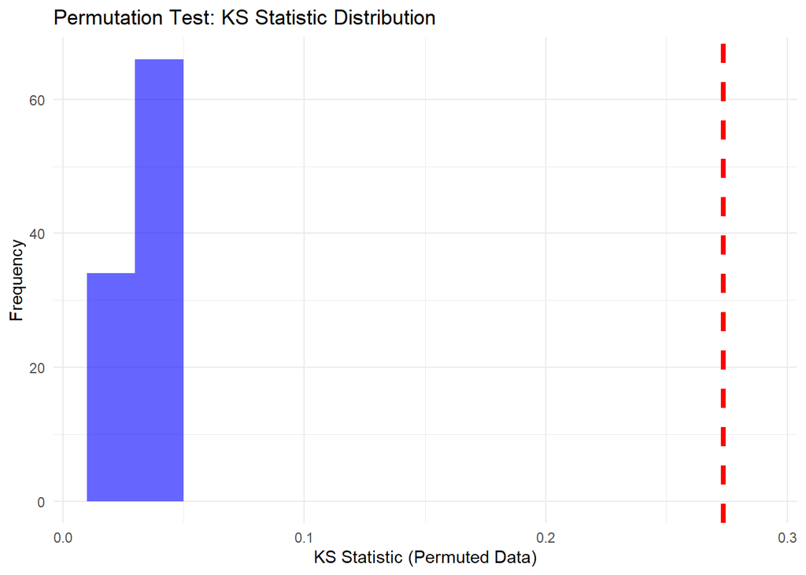

```r
perm_df_34 <- data.frame(perm_values_34)

ggplot(perm_df_34, aes(x = perm_values_34)) +
  geom_histogram(binwidth = 0.02, fill = "blue", alpha = 0.6) +
  geom_vline(xintercept = ks_23, color = "red", linetype = "dashed", size = 1.5) +
  labs(title = "Permutation Test: KS Statistic Distribution",
       x = "KS Statistic (Permuted Data)",
       y = "Frequency") +
  theme_minimal()
```

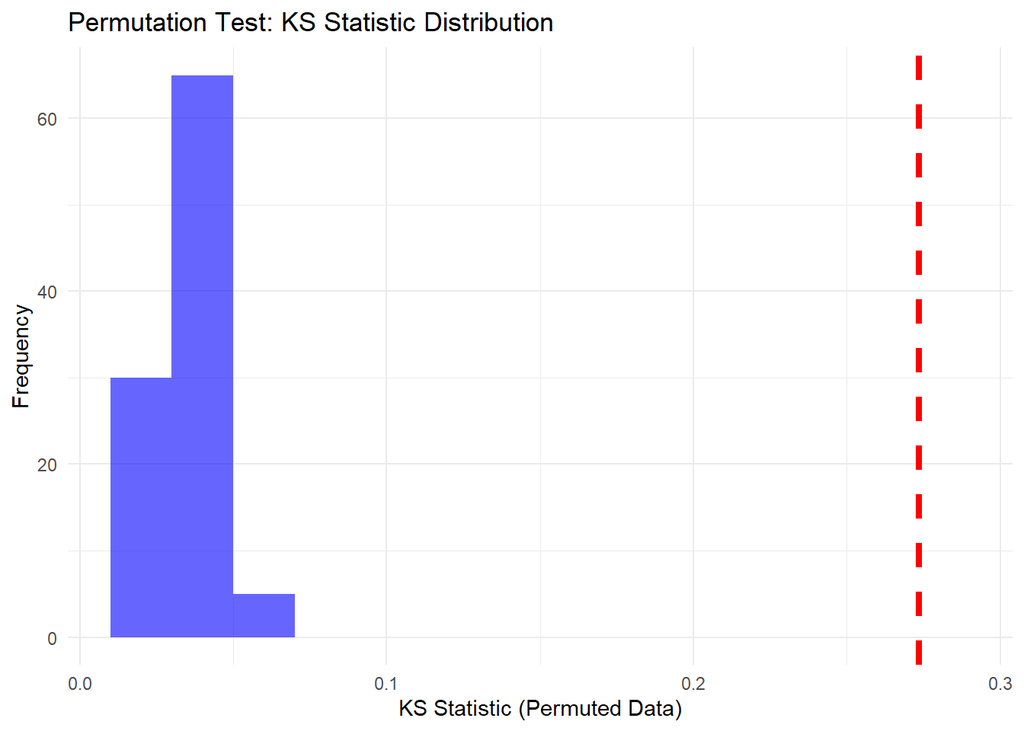

```r
perm_df_24 <- data.frame(perm_values_24)

ggplot(perm_df_24, aes(x = perm_values_24)) +
  geom_histogram(binwidth = 0.02, fill = "blue", alpha = 0.6) +
  geom_vline(xintercept = ks_23, color = "red", linetype = "dashed", size = 1.5) +
  labs(title = "Permutation Test: KS Statistic Distribution",
       x = "KS Statistic (Permuted Data)",
       y = "Frequency") +
  theme_minimal()
```

Those plots are so bad to see :(

Let’s try additional tests, coming from the easier solution we applied on HW2

```r
ks_23 <- ks.test(pred_probs[df_multiclass$HR_Zone == 0, 2],
                 pred_probs[df_multiclass$HR_Zone == 1, 2])

ks_34 <- ks.test(pred_probs[df_multiclass$HR_Zone == 1, 3],
                 pred_probs[df_multiclass$HR_Zone == 2, 3])

ks_24 <- ks.test(pred_probs[df_multiclass$HR_Zone == 0, 3],
                 pred_probs[df_multiclass$HR_Zone == 2, 3])

alpha <- 0.05
m <- 3
alpha_corrected <- alpha / m

cat("KS Statistic Zone-2 vs Zone-3:", ks_23$statistic, "p-value:", ks_23$p.value, "\n")
```

```
## KS Statistic Zone-2 vs Zone-3: 0.2734144 p-value: 0
```

```r
cat("KS Statistic Zone-3 vs Zone-4:", ks_34$statistic, "p-value:", ks_34$p.value, "\n")
```

```
## KS Statistic Zone-3 vs Zone-4: 0.4569934 p-value: 0
```

```r
cat("KS Statistic Zone-2 vs Zone-4:", ks_24$statistic, "p-value:", ks_24$p.value, "\n")
```

```
## KS Statistic Zone-2 vs Zone-4: 0.7911595 p-value: 0
```

```r
cat("\nSignificance after Bonferroni Correction (α =", alpha_corrected, ")\n")
```

```
##
## Significance after Bonferroni Correction (α = 0.01666667 )
```

```r
cat("Reject H0 (Z2 vs Z3)?:", ks_23$p.value < alpha_corrected, "\n")
```

```
## Reject H0 (Z2 vs Z3)?: TRUE
```

```r
cat("Reject H0 (Z3 vs Z4)?:", ks_34$p.value < alpha_corrected, "\n")
```

```
## Reject H0 (Z3 vs Z4)?: TRUE
```

```r
cat("Reject H0 (Z2 vs Z4)?:", ks_24$p.value < alpha_corrected, "\n")
```

```
## Reject H0 (Z2 vs Z4)?: TRUE
```

Bonferroni-corrected KS tests confirm that all HR Zones are distinct from each other.

```r
library(car)  # ANOVA
#install.packages("multcomp")
library(multcomp)  # No need cause p value <0.05
anova_data <- data.frame(
  HR_Zone = df_multiclass$HR_Zone,
  Prob_Z2 = pred_probs[, 1],  # Probability of being in Zone-2
  Prob_Z3 = pred_probs[, 2],  # Probability of being in Zone-3
  Prob_Z4 = pred_probs[, 3]   # Probability of being in Zone-4
)

anova_z2 <- aov(Prob_Z2 ~ HR_Zone, data = anova_data)
anova_z3 <- aov(Prob_Z3 ~ HR_Zone, data = anova_data)
anova_z4 <- aov(Prob_Z4 ~ HR_Zone, data = anova_data)

cat("ANOVA for Zone-2 Probabilities:\n")
```

```
## ANOVA for Zone-2 Probabilities:
```

```r
print(summary(anova_z2))
```

```
##                Df Sum Sq Mean Sq F value Pr(>F)
## HR_Zone         2  312.3  156.14    5319 <2e-16 ***
## Residuals   18273  536.4    0.03
## ---
## Signif. codes:  0 '***' 0.001 '**' 0.01 '*' 0.05 '.' 0.1 ' ' 1
```

```r
cat("\nANOVA for Zone-3 Probabilities:\n")
```

```
##
## ANOVA for Zone-3 Probabilities:
```

```r
print(summary(anova_z3))
```

```
##                Df Sum Sq Mean Sq F value Pr(>F)
## HR_Zone         2   78.7   39.34    1647 <2e-16 ***
## Residuals   18273  436.3    0.02
## ---
## Signif. codes:  0 '***' 0.001 '**' 0.01 '*' 0.05 '.' 0.1 ' ' 1
```

```r
cat("\nANOVA for Zone-4 Probabilities:\n")
```

```
##
## ANOVA for Zone-4 Probabilities:
```

```r
print(summary(anova_z4))
```

```
##                Df Sum Sq Mean Sq F value Pr(>F)
## HR_Zone         2  440.7  220.35    5781 <2e-16 ***
## Residuals   18273  696.5    0.04
## ---
## Signif. codes:  0 '***' 0.001 '**' 0.01 '*' 0.05 '.' 0.1 ' ' 1
```

ANOVA confirms significant differences in probability distributions across HR Zones.